# Rapport de stage - Code R

2025-07-09

Ce document Markdown présente l’ensemble des étapes de préparation, de traitement et d’exploration des données, ainsi que les résultats obtenus pour la réalisation de mon rapport de stage.

Ce document a été structuré dans un souci de clarté et de traçabilité, afin de faciliter la lisibilité des analyses de mon rapport.

```r
library(readxl)
library(dplyr)
library(ineq)
export<- read_excel("C:/Users/Utilisateur/OneDrive/Documents/Stage CHU/export_sc_comapratif.xlsx")
iris <- read_excel("C:/Users/Utilisateur/Downloads/20241104-edi2017-iris.xlsx")
export <- export %>%
  mutate(IRIS = as.numeric(IRIS))
iris <- iris %>%
  mutate(IRIS = as.numeric(IRIS))
```

Comme je n’ai pas accès aux données de la SNDS, j’utilise les données de Frontiers(Table 2 dans le code) pour calculer l’espérance de vie restantante des individus pour chaque quintile d’EDI selon le guide le guide de Anya Hageman and Pauline Galoustian.

```r
expvie<-function(df){
  #qx le quotient de mortalité à l'age x
  df$qx<-1
  df$qx[df$AGE != 100] <- df$mx[df$AGE != 100] / (1 + 0.5 * df$mx[df$AGE != 100])

  #lx , le nombre d'individus toujours en vie dans la catégorie
  df$lx <-100000
  for (i in 7:nrow(df)) {
    df$lx[i] <- (1-df$qx[i - 6]) * df$lx[i-6]} #car 5 +1 quintiles

  #Nombre de morts dans l annee
  df$dead <- df$lx * df$mx

  #Calcul de Lx qui représente le nombre total d'années vécues
  #dans ce groupe d'âge par tous ceux qui ont atteint cet âge
  df$Lx <- NA
  df$Tx <- NA

  f <- 0.5 #centre au milieu de l'annee

  df$Lx <- df$lx - f * df$dead
  df$Lx[df$AGE == 100] <- df$lx[df$AGE == 100] / df$mx[df$AGE == 100]

  # 2. Calcul de Tx qui représente le nombre total d'années vécues par ce groupe d'âge à partir de cet âge.

  n_suites <- 6 # 5 quantiles + Total
  n_termes <- 83 # (100-18+1)

  for (j in 1:n_suites) {
    indices <- seq(j, by=n_suites, length.out=n_termes)
    suite <- df$Lx[indices]

    somme_inverse <- rev(cumsum(rev(suite)))

    for (i in 1:n_termes) {
      index_global <- 6 * (i - 1) + j
      df$Tx[index_global] <- somme_inverse[i]
    }
  }

  # Calcul de ex
  df$ex_calcule <- df$Tx / df$lx

  return(df)}

Table_2 <- read_excel("D:/telechargements/Table 2.XLSX")
table_3<-expvie(Table_2)
```

Ensuite cette esperance de vie est associée aux individus simulés :

```r
ages_pop <- c(50, 55, 60, 65, 70)

table_3 <- table_3 %>%
  mutate(QEDI = as.numeric(QEDI))
table_ex <- table_3 %>%
  filter(AGE %in% ages_pop, SEX == "Females") %>%
  select(AGE, QEDI, ex_calcule) %>%
  na.omit()

export_sc <- inner_join(export,iris, by ="IRIS")

export_sc <- export_sc %>%
  left_join(table_ex, by = c("Age" = "AGE", "quintileedi2017" = "QEDI"))%>%
  rename(expdeviesanscancer = ex_calcule)
```

Evolution de la participation au programme.

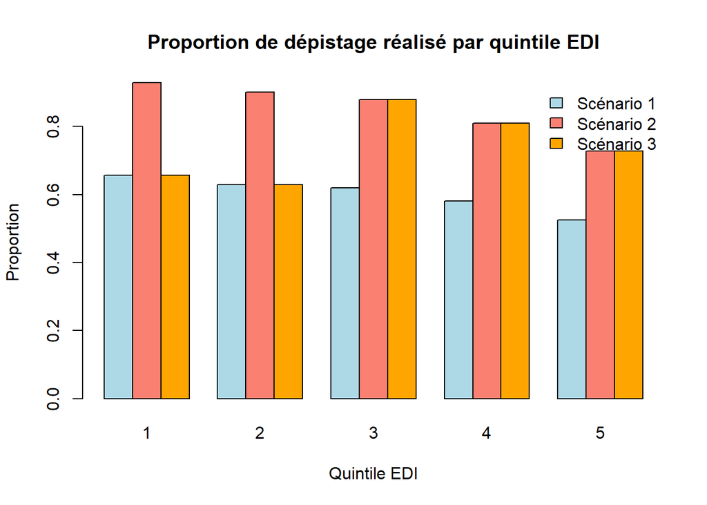

```r
tab1 <- prop.table(table(export_sc$quintileedi2017, export_sc$Dépistage_scenario1), margin = 1)
tab2 <- prop.table(table(export_sc$quintileedi2017, export_sc$Dépistage_scenario2), margin = 1)
tab3 <- prop.table(table(export_sc$quintileedi2017, export_sc$Dépistage_scenario3), margin = 1)

tab_oui <- cbind(tab1[, "Oui"], tab2[, "Oui"], tab3[, "Oui"])
colnames(tab_oui) <- c("Scénario 1", "Scénario 2", "Scénario 3")

bp <- barplot(t(tab_oui),
              beside = TRUE,
              col = c("lightblue", "salmon", "orange"),
              legend.text = colnames(tab_oui),
              args.legend = list(x = "topright", bty = "n"),
              main = "Proportion de dépistage réalisé par quintile EDI",
              xlab = "Quintile EDI",
              ylab = "Proportion")
```

Afin de comparer les durées de vie ajustées par la qualité (QALE) il faut dans un premier temps simuler des âges de décès.

```r
fusion  <- export_sc %>%
  filter(`Detection Time (TD)`>50 , `Tumor Onset` <=70)

diameter <- function(volume){
  return((6*volume/pi)^(1/3))
}

survie_t <- function(tumor_size_mm, r, alpha = 6e-4, c = 4e-3) {
  lambda <- alpha * tumor_size_mm + c / r
  return(dexp(1,rate = lambda))
}

simuler_age_deces_cancer <- function(age,taux,ex,onset) {
  if (onset < age + ex ){
    return(age+(ex*(1-taux)^(ex)))}
  else {return(age+ex)}
}

for ( i in 1:nrow(fusion)){
  fusion$screening_volume[i]<- 4/3*pi*(0.5/2)^3*exp((fusion$`Screening Time (T_screen)`[i]-fusion$`Tumor Onset`[i])/fusion$`Growth Rate (R)`[i])

  #Diametres
  fusion$diam_scre[i] <- diameter(fusion$screening_volume[i])
  fusion$diam_det[i] <- diameter(fusion$`Detection Volume (D)`[i])

  d_screen <- min(fusion$diam_scre[i], fusion$diam_det[i])
  d_det <- fusion$diam_det[i]
  r <- fusion$`Growth Rate (R)`[i]

  # Calcul des taux de survie
  survie_scre <- survie_t(d_screen, r)
  survie_det <- survie_t(d_det, r)           #cond sup scre>det ? vu que va


  if (fusion$Dépistage_scenario1[i] == "Oui") {
    t =survie_scre
  } else {
    t <- survie_det}

  if (fusion$Dépistage_scenario2[i] == "Oui") {
      s <- survie_scre
    } else {
      s <- survie_det
    }
  if (fusion$Dépistage_scenario3[i] == "Oui") {
      v <- survie_scre
    } else {
      v <- survie_det
    }

  # Estimation de décès
  fusion$expdevieaveccancer_scenar1_t[i] <- simuler_age_deces_cancer(
    fusion$Age[i], t, fusion$expdeviesanscancer[i], fusion$`Tumor Onset`[i])
  fusion$expdevieaveccancer_scenar2_t[i] <- simuler_age_deces_cancer(
    fusion$Age[i], s, fusion$expdeviesanscancer[i], fusion$`Tumor Onset`[i])
  fusion$expdevieaveccancer_scenar3_t[i] <- simuler_age_deces_cancer(
    fusion$Age[i], v, fusion$expdeviesanscancer[i], fusion$`Tumor Onset`[i])
}
```

A partir de ces espérances de vie, on peut calculer les QALE associés, les scores utilisés correspondent à ceux publiés par Kind, Hardman et Macran.

```r
QALY_Param <- data.frame(
  AGE =  c("18-25", "25-34", "35-44", "45-54", "55-64", "65-74", "75+"),
  Score_Female = c(0.94, 0.93, 0.91, 0.85, 0.81, 0.78, 0.71),
  ageborne = c(18, 25, 35, 45, 55, 65, 75))

#Note : les scores commencent à 18ans

calculduqaly <- function(ex) {
  qaly <- 0
  for (i in 1:(nrow(QALY_Param) - 1)) {
    if (ex >= QALY_Param$ageborne[i+1]) {
      qaly <- qaly + (QALY_Param$ageborne[i+1] - QALY_Param$ageborne[i]) * QALY_Param$Score_Female[i]}

    else if (ex > QALY_Param$ageborne[i]) {
      qaly <- qaly + (ex - QALY_Param$ageborne[i]) * QALY_Param$Score_Female[i]
      return(qaly)}}

  if (ex > 75) {
    qaly <- qaly + (ex - 75) * QALY_Param$Score_Female[QALY_Param$AGE == "75+"]}

  return(qaly)}


fusion$qaly1 <- sapply(fusion$expdevieaveccancer_scenar1_t, function(x) {
  if (is.na(x)) return(NA)
  else calculduqaly(x)
})
fusion$qaly2 <- sapply(fusion$expdevieaveccancer_scenar2_t, function(x) {
  if (is.na(x)) return(NA)
  else calculduqaly(x)
})
fusion$qaly3 <- sapply(fusion$expdevieaveccancer_scenar3_t, function(x) {
  if (is.na(x)) return(NA)
  else calculduqaly(x)
})
#Et sans cancer :

fusion$qalysanscancer <- sapply((fusion$expdeviesanscancer + fusion$Age) , function(x) {
  if (is.na(x)) return(NA)
  else calculduqaly(x)
})

export_sc$qalysanscancer <- sapply((export_sc$expdeviesanscancer + export_sc$Age) , function(x) {
  if (is.na(x)) return(NA)
  else calculduqaly(x)
})
```

Toujours conformément au guide méthodologique, il faut maintenant ajuster les score par apport aux DFLE :

N’ayant une nouvelle fois pas accès à cette valeur, je la génére suivant une variable aléatoire.

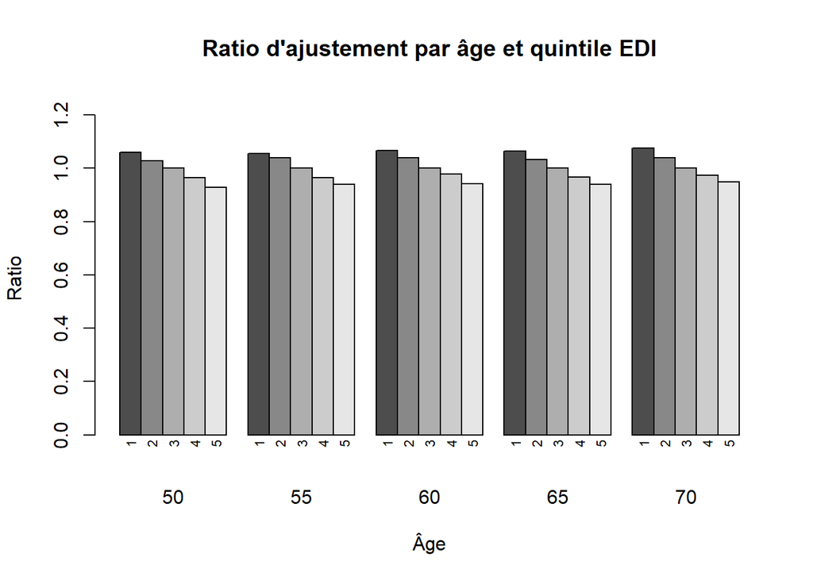

```r
liste_resultats=NA
for (a in ages_pop) {
  res <- export_sc %>%
    group_by(quintileedi2017) %>%
    summarise(
      Age=a,
      moyenne_ex = mean(expdeviesanscancer + a, na.rm = TRUE),
      moyenne_qaly = mean(qalysanscancer, na.rm = TRUE),
      .groups = "drop"
    )
  liste_resultats=rbind(liste_resultats,res)
}
moyenne_ex_par_qedi=liste_resultats[-1,]

moyenne_ex_par_qedi$va_dfle_ajuste <- rnorm(n = nrow(moyenne_ex_par_qedi),
                                            mean = moyenne_ex_par_qedi$moyenne_qaly - 2 - 1.5*moyenne_ex_par_qedi$quintileedi2017,sd = 0.2)


calcul_ratio <- function(df) {
  df %>%
    group_by(Age) %>%
    mutate(
      ratio = va_dfle_ajuste / moyenne_ex,
      ratio_ajuste = ratio / ratio[quintileedi2017 == 3]
    ) %>%
    ungroup()
}
moyenne_ex_par_qedi <- calcul_ratio(moyenne_ex_par_qedi)

fusion <- fusion %>%
  left_join(
    moyenne_ex_par_qedi %>% select(quintileedi2017,Age, ratio_ajuste),
    by = c("quintileedi2017","Age"))

fusion$qaly1=fusion$qaly1*fusion$ratio_ajuste
fusion$qaly2=fusion$qaly2*fusion$ratio_ajuste
fusion$qaly3=fusion$qaly3*fusion$ratio_ajuste

#graphique
vect <- xtabs(ratio_ajuste ~ Age + quintileedi2017, data = moyenne_ex_par_qedi)
ages <- colnames(vect)
bp_ratio <- barplot(t(vect),
              beside = TRUE,
              ylim = c(-0.1, max(vect) + 0.2),
              main = "Ratio d'ajustement par âge et quintile EDI",
              xlab = "Âge",
              ylab = "Ratio")
quintiles <- c("1","2","3","4","5")
for (i in 1:5) {
    for (j in 1:5) {
        text(x = bp_ratio[j, i], y = -0.02, labels = quintiles[j], cex = 0.7, srt = 90, adj = 1)
    }
}
```

Mais l’utilité dépend aussi du type de cancer, il faut donc l’ajuster en fonction :

```r
stage_utility <- data.frame(
  Stage =  c("In situ", "Invasif", "Métastatique"),
  adjusted_score = c(0.85, 0.75, 0.4)) #scores arbitraires, à titre exploratoires

calculduqaly_stage <- function(ex, onset, region, distant, qaly,screened,detected,depistage_sc) {
  if (any(is.na(c(ex, onset, region, distant, qaly)))) return(NA)

  u_insitu <- stage_utility$adjusted_score[stage_utility$Stage == "In situ"]
  u_invasif <- stage_utility$adjusted_score[stage_utility$Stage == "Invasif"]
  u_metastatique <- stage_utility$adjusted_score[stage_utility$Stage == "Métastatique"]

  if (depistage_sc == "Oui") {
    T_insitu <- max(0, min(region, detected, screened, ex) - onset)
    T_invasif <- max(0, min(distant, screened,detected, ex) - region)
    T_meta <- max(0, ex - distant)

    q <- qaly -
      T_insitu * (1 - u_insitu) -
      T_invasif * (1 - u_invasif) -
      T_meta * (1 - u_metastatique)}
  else {
    T_insitu <- max(0, min(region, detected, ex) - onset)
    T_invasif <- max(0, min(distant, detected, ex) - region)
    T_meta <- max(0, ex - distant)

    q <- qaly -
      T_insitu * (1 - u_insitu) -
      T_invasif * (1 - u_invasif) -
      T_meta * (1 - u_metastatique)}

  return(q)}

#Application :
fusion$`Distant Transition Time (TM)`[fusion$`Distant Transition Time (TM)` == "inf"] <- Inf   #sinon caracteres
fusion$`Distant Transition Time (TM)` <- as.numeric(fusion$`Distant Transition Time (TM)`)

fusion$qaly_stage1 <- mapply(calculduqaly_stage,
                             ex=fusion$expdevieaveccancer_scenar1_t,
                             onset=fusion$`Tumor Onset`,
                             region = fusion$`Regional Transition Time (TN)`,
                             distant= fusion$`Distant Transition Time (TM)`,
                             qaly=fusion$qaly1,
                             screened=fusion$`Screening Time (T_screen)`,
                             detected=fusion$`Detection Time (TD)`,
                             depistage_sc=fusion$Dépistage_scenario1)

fusion$qaly_stage2 <- mapply(calculduqaly_stage,
                             ex=fusion$expdevieaveccancer_scenar2_t,
                             onset=fusion$`Tumor Onset`,
                             region = fusion$`Regional Transition Time (TN)`,
                             distant= fusion$`Distant Transition Time (TM)`,
                             qaly=fusion$qaly2,
                             screened=fusion$`Screening Time (T_screen)`,
                             detected=fusion$`Detection Time (TD)`,
                             depistage_sc=fusion$Dépistage_scenario2)

fusion$qaly_stage3 <- mapply(calculduqaly_stage,
                             ex=fusion$expdevieaveccancer_scenar3_t,
                             onset=fusion$`Tumor Onset`,
                             region = fusion$`Regional Transition Time (TN)`,
                             distant= fusion$`Distant Transition Time (TM)`,
                             qaly=fusion$qaly3,
                             screened=fusion$`Screening Time (T_screen)`,
                             detected=fusion$`Detection Time (TD)`,
                             depistage_sc=fusion$Dépistage_scenario3)
```

## Estimation des différents coûts

```r
#cout du test 66,42 #source google
#bdd complete pour cout de la campagne
export_sc$cout_indiv <- rnorm(n = nrow(export_sc),mean = 66.42, sd = 4)
export_sc$cout_indiv_transp <- rnorm(n = nrow(export_sc),mean = 30, sd = 10)

cout_ind_tot <- function(age, screen, ex, cout_i, scenario) {
  if (scenario == "Oui") {
    if (screen < ex) { #un cancer detecte avant la mort
      if ((screen - age) > 2) {
        return(trunc((screen - age) / 2) * cout_i)  # dépistage jusqu'à détection
      } else {
        return(cout_i)
      }
    } else if ((ex - age) > 2) { #pas de cancer détecté, mais dépistage régulier
      return(trunc((ex - age) / 2) * cout_i)        # jusqu’à décès

    } else { #  espérance de vie < 2 ans 1 sceance
      return(cout_i)
    }

  } else {
    return(0)  # Pas de participation au programme
  }
}

#Pour le transport

cout_ind_tot_sc2 <- function(cout_tr, scenario) {
  if (scenario == "Oui") { return(cout_tr)
  } else {
    return(0)
  }
}

cout_ind_tot_sc3 <- function(cout_tr, scenario,quint) {
  if (scenario == "Oui") {
    if (quint %in% c(3,4,5)) {return(cout_tr) }
    else {
      return(0)}
  }
  else{return(0)}
}
export_sc$cout_total_i_scenario1 <- mapply(cout_ind_tot,
                                          age=export_sc$Age,
                                          screen = export_sc$`Screening Time (T_screen)`,
                                          ex=(export_sc$expdeviesanscancer +export_sc$Age),
                                          scenario = export_sc$Dépistage_scenario1,
                                          cout_i = export_sc$cout_indiv)

export_sc$cout_total_i_scenario2 <- mapply(cout_ind_tot,
                                          age=export_sc$Age,
                                          screen = export_sc$`Screening Time (T_screen)`,
                                          ex=(export_sc$expdeviesanscancer +export_sc$Age),
                                          scenario = export_sc$Dépistage_scenario2,
                                          cout_i = export_sc$cout_indiv)

export_sc$cout_total_i_scenario3 <- mapply(cout_ind_tot,
                                           age=export_sc$Age,
                                           screen = export_sc$`Screening Time (T_screen)`,
                                           ex=(export_sc$expdeviesanscancer +export_sc$Age),
                                           scenario = export_sc$Dépistage_scenario3,
                                           cout_i = export_sc$cout_indiv)
#Pour le transport
export_sc$cout_total_i_transp_sc2 <- mapply(cout_ind_tot_sc2 ,
                                           cout_tr=export_sc$cout_indiv_transp,
                                           scenario = export_sc$Dépistage_scenario2)

export_sc$cout_total_i_transp_sc3 <- mapply(cout_ind_tot_sc3 ,
                                            cout_tr=export_sc$cout_indiv_transp,
                                            scenario =export_sc$Dépistage_scenario3,
                                            quint=export_sc$quintileedi2017)
```

Le coût de l’hospitalisation dépend du stade de détection :

```r
fusion$cout1 <- rnorm(n = nrow(fusion), mean = 3000, sd = 300)
fusion$cout2 <- rnorm(n = nrow(fusion), mean = 12000, sd = 1200)
fusion$cout3 <- rnorm(n = nrow(fusion), mean = 40000, sd = 4000)
cout_traitement <- function(ex, screentime, dettime, stage ,stagescreen , scenario,cout1,cout2,cout3) {
  if (any(is.na(c(ex, screentime, dettime, stage ,stagescreen , scenario)))) return(NA)
  if (scenario == "Oui") {
    if (screentime < ex) {
      if (stagescreen == "In situ") {
        return(cout1)
      } else if (stagescreen == "Invasif") {
        return(cout2)
      } else if (stagescreen == "Métastatique") {
        return(cout3)}
    } else {
      return(0)}
  } else {
    if (dettime < ex) {
      if (stage == "In situ") {
        return(cout1)
      } else if (stage == "Invasif") {
        return(cout2)
      } else if (stage == "Métastatique") {
        return(cout3)
      }
    } else {return(0)}}}

max_volume_sc <- max(fusion$screening_volume[is.finite(fusion$screening_volume)], na.rm = TRUE)
fusion$screening_volume[is.infinite(fusion$screening_volume)] <- max_volume_sc
max_diam<- max(fusion$diam_scre[is.finite(fusion$diam_scre)], na.rm = TRUE)
fusion$diam_scre[is.infinite(fusion$diam_scre)] <- max_diam

fusion$`Distant Transition Time (TM)`[fusion$`Distant Transition Time (TM)` == "inf"] <- Inf   #sinon caracteres
fusion$`Distant Transition Time (TM)` <- as.numeric(fusion$`Distant Transition Time (TM)`)

fusion$cout_hospitalisation1 <- mapply(cout_traitement,
                                       ex = fusion$expdevieaveccancer_scenar1_t,
                                       screentime=fusion$`Screening Time (T_screen)`,
                                       dettime = fusion$`Detection Time (TD)`,
                                       stage =fusion$Stage,
                                       stagescreen = fusion$`Stage screened`,
                                       scenario = fusion$Dépistage_scenario1,
                                       cout1=fusion$cout1,
                                       cout2=fusion$cout2,
                                       cout3=fusion$cout3)

fusion$cout_hospitalisation2 <- mapply(cout_traitement,
                                       ex = fusion$expdevieaveccancer_scenar2_t,
                                       screentime=fusion$`Screening Time (T_screen)`,
                                       dettime = fusion$`Detection Time (TD)`,
                                       stage =fusion$Stage,
                                       stagescreen = fusion$`Stage screened`,
                                       scenario = fusion$Dépistage_scenario2,
                                       cout1=fusion$cout1,
                                       cout2=fusion$cout2,
                                       cout3=fusion$cout3)

fusion$cout_hospitalisation3 <- mapply(cout_traitement,
                                       ex = fusion$expdevieaveccancer_scenar3_t,
                                       screentime=fusion$`Screening Time (T_screen)`,
                                       dettime = fusion$`Detection Time (TD)`,
                                       stage =fusion$Stage,
                                       stagescreen = fusion$`Stage screened`,
                                       scenario = fusion$Dépistage_scenario3,
                                       cout1=fusion$cout1,
                                       cout2=fusion$cout2,
                                       cout3=fusion$cout3)
```

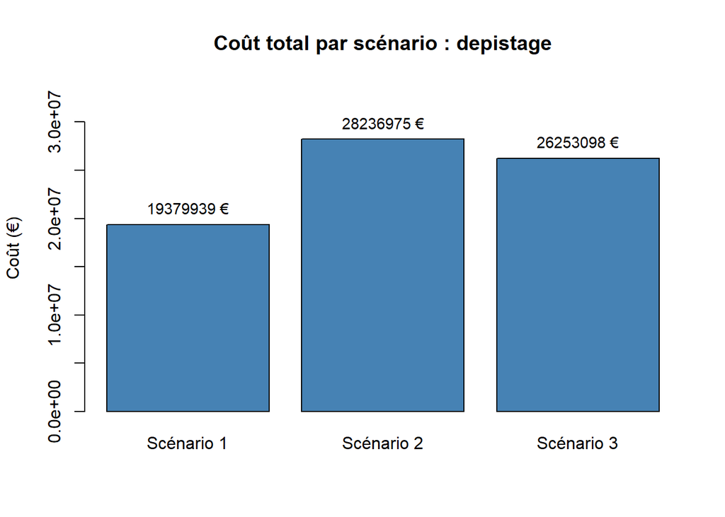

```r
#Graphiquement
cout_tot1<-sum(export_sc$cout_total_i_scenario1, na.rm = TRUE)
cout_tot2<-sum(export_sc$cout_total_i_scenario2+export_sc$cout_total_i_transp_sc2, na.rm = TRUE)
cout_tot3<-sum(export_sc$cout_total_i_scenario3+export_sc$cout_total_i_transp_sc3, na.rm = TRUE)

couts <- c("Scénario 1" = cout_tot1, "Scénario 2" = cout_tot2,"Scénario 3" = cout_tot3)
bp <- barplot(couts,
              col = "steelblue",
              main = "Coût total par scénario : depistage",
              ylab = "Coût (€)",
              ylim = c(0, max(couts) * 1.2))

text(x = bp,          #Ajouter les valeurs au-dessus des barres
     y = couts,
     labels = paste0(round(couts), " €"),
     pos = 3, cex = 0.9)
```

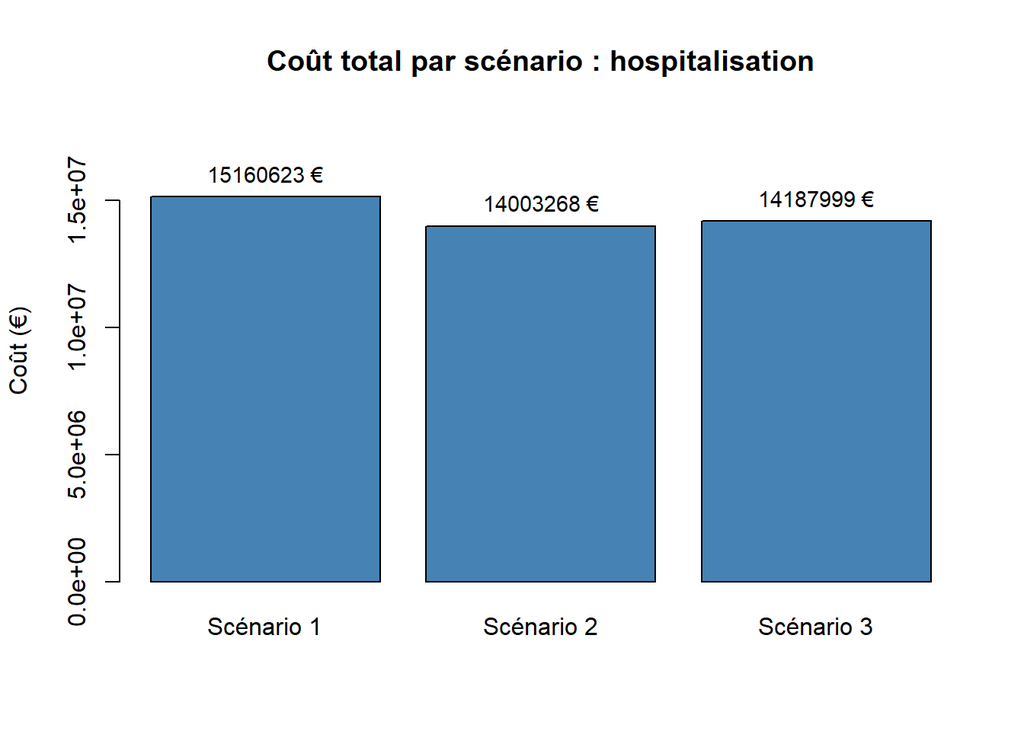

```r
cout_tot_hospi1<-sum(fusion$cout_hospitalisation1, na.rm = TRUE)
cout_tot_hospi2<-sum(fusion$cout_hospitalisation2, na.rm = TRUE)
cout_tot_hospi3<-sum(fusion$cout_hospitalisation3, na.rm = TRUE)


couts_hospi <- c("Scénario 1" = cout_tot_hospi1, "Scénario 2" = cout_tot_hospi2,"Scénario 3" = cout_tot_hospi3)

bp_hospi <- barplot(couts_hospi,
                    col = "steelblue",
                    main = "Coût total par scénario : hospitalisation",
                    ylab = "Coût (€)",
                    ylim = c(0, max(couts_hospi) * 1.2))

text(x = bp_hospi,
     y = couts_hospi,
     labels = paste0(round(couts_hospi), " €"),
     pos = 3, cex = 0.9)
```

A partir de ces coûts, on peut en déduire le cout d’opportunité :

```r
qaly_euro <- 24000

tab_des_couts <- data.frame(
  Scénario = c("Scénario 1", "Scénario 2", "Scénario 3"),
  Cout_du_depistage = c(cout_tot1, cout_tot2, cout_tot3),
  Cout_hospitalisation = c(cout_tot_hospi1, cout_tot_hospi2, cout_tot_hospi3)
)

tab_des_couts$Difference_depis <- tab_des_couts$Cout_du_depistage - tab_des_couts$Cout_du_depistage[1]
tab_des_couts$Difference_hospi <- tab_des_couts$Cout_hospitalisation - tab_des_couts$Cout_hospitalisation[1]
# Coût d'opportunité (division par qaly_euro)
tab_des_couts$Cout_opportunite <- (tab_des_couts$Difference_depis + tab_des_couts$Difference_hospi) / qaly_euro
print(tab_des_couts)
```

```
##     Scénario Cout_du_depistage Cout_hospitalisation Difference_depis
## 1 Scénario 1          19379939             15160623                0
## 2 Scénario 2          28236975             14003268          8857036
## 3 Scénario 3          26253098             14187999          6873159
##   Difference_hospi Cout_opportunite
## 1              0.0           0.0000
## 2       -1157355.4         320.8200
## 3        -972624.2         245.8556
```

```r
#Tableau Latex:

#library(knitr)
#tab_des_couts %>%
#  kable(format = "latex", booktabs = TRUE)

#Et le coût d'opportunité est integré

base_effectifs <- data.frame(
  quintileedi2017 = c(1,2,3,4,5),
  effectif=as.vector(table(fusion$quintileedi2017)))

fusion <- fusion %>%
  left_join(base_effectifs, by = "quintileedi2017") %>%
  mutate(qaly_stage_final2 = qaly_stage2 - 317.7431 / effectif,
         qaly_stage_final3 = qaly_stage3 - 243.5390 / effectif)
```

Mesures d’inégalité calculées pour les stratégies de dépistage :

```r
gini1=Gini(fusion$qaly_stage1)
gini2=Gini(fusion$qaly_stage_final2)
gini3=Gini(fusion$qaly_stage_final3)

a1_1=Atkinson(fusion$qaly_stage1, parameter = 1)
a1_7=Atkinson(fusion$qaly_stage1, parameter = 7)
a1_30=Atkinson(fusion$qaly_stage1, parameter = 30)

a2_1=Atkinson(fusion$qaly_stage_final2, parameter = 1)
a2_7=Atkinson(fusion$qaly_stage_final2, parameter = 7)
a2_30=Atkinson(fusion$qaly_stage_final2, parameter = 30)

a3_1=Atkinson(fusion$qaly_stage_final3, parameter = 1)
a3_7=Atkinson(fusion$qaly_stage_final3, parameter = 7)
a3_30=Atkinson(fusion$qaly_stage_final3, parameter = 30)

#

k1_025=Kolm(fusion$qaly_stage1, parameter = 0.025)
k1_01=Kolm(fusion$qaly_stage1, parameter = 0.1)
k1_05=Kolm(fusion$qaly_stage1, parameter = 0.5)

k2_025=Kolm(fusion$qaly_stage_final2, parameter = 0.025)
k2_01=Kolm(fusion$qaly_stage_final2, parameter = 0.1)
k2_05=Kolm(fusion$qaly_stage_final2, parameter = 0.5)

k3_025=Kolm(fusion$qaly_stage_final3, parameter = 0.025)
k3_01=Kolm(fusion$qaly_stage_final3, parameter = 0.1)
k3_05=Kolm(fusion$qaly_stage_final3, parameter = 0.5)



indices_inegalite <- data.frame(
  Scénario = c("Scénario 1", "Scénario 2", "Scénario 3"),
  Gini = c(gini1, gini2, gini3),
  Atkinson_1 = c(a1_1, a2_1, a3_1),
  Atkinson_7 = c(a1_7, a2_7, a3_7),
  Atkinson_30 = c(a1_30, a2_30, a3_30),
  kolm_025 = c(k1_025,k2_025,k3_025),
  kolm_01 = c(k1_01,k2_01,k3_01),
  kolm_05 = c(k1_05,k2_05,k3_05)

)


print(indices_inegalite)
```

```
##     Scénario       Gini Atkinson_1 Atkinson_7 Atkinson_30  kolm_025  kolm_01
## 1 Scénario 1 0.08674386 0.01227458 0.09557884   0.2754586 0.5855168 2.388342
## 2 Scénario 2 0.08517389 0.01202456 0.09624561   0.2813232 0.5733533 2.374678
## 3 Scénario 3 0.08474553 0.01189344 0.09516119   0.2795303 0.5666740 2.348157
##    kolm_05
## 1 9.185926
## 2 9.378252
## 3 9.297913
```

Régles de dominance :

```r
#Dominance standard
qaly_par_quintile <- fusion %>%
     group_by(quintileedi2017) %>%
      summarise(
          QALE_scenar1 = mean(qaly_stage1, na.rm = TRUE),
          QALE_scenar2 = mean(qaly_stage2, na.rm = TRUE),
          QALE_scenar3 = mean(qaly_stage3, na.rm = TRUE),
          .groups = "drop")
print(qaly_par_quintile)
```

```
## # A tibble: 5 x 4
##   quintileedi2017 QALE_scenar1 QALE_scenar2 QALE_scenar3
##             <dbl>        <dbl>        <dbl>        <dbl>
## 1               1         50.5         51.1         50.5
## 2               2         47.9         48.6         47.9
## 3               3         45.9         46.6         46.6
## 4               4         44.3         44.8         44.8
## 5               5         42.9         43.4         43.4
```

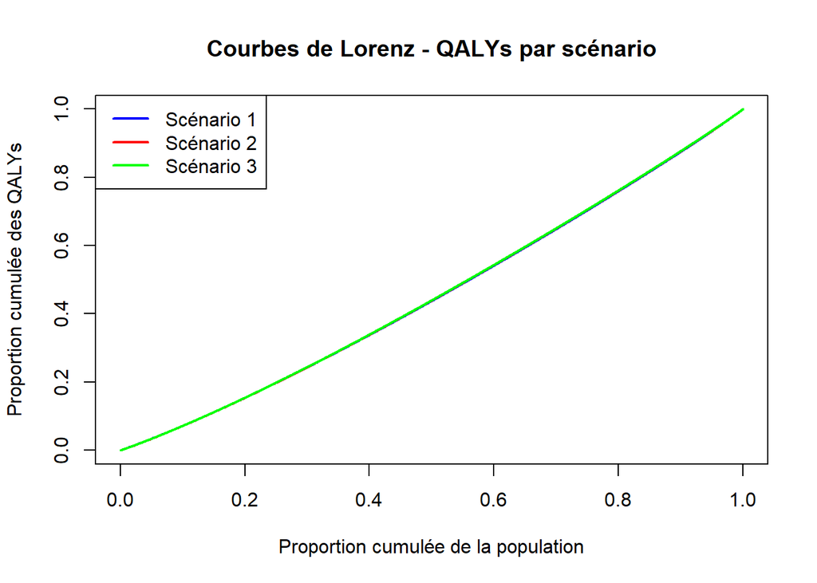

```r
#Théorème Atkinson

Lc1 <- Lc(fusion$qaly_stage1)
Lc2 <- Lc(fusion$qaly_stage_final2)
Lc3 <- Lc(fusion$qaly_stage_final3)

plot(Lc1$p, Lc1$L, type = "l", col = "blue", lwd = 2,
     xlab = "Proportion cumulée de la population",
     ylab = "Proportion cumulée des QALYs",
     main = "Courbes de Lorenz - QALYs par scénario")

lines(Lc2$p, Lc2$L, col = "red", lwd = 2)
lines(Lc3$p, Lc3$L, col = "green", lwd = 2)
legend("topleft", legend = c("Scénario 1", "Scénario 2", "Scénario 3"),
       col = c("blue", "red", "green"), lty = 1, lwd = 2)
```

```r
diff_lorentz_df <- data.frame(
  diff_12= Lc1$L - Lc2$L,
  diff_13= Lc1$L - Lc3$L,
  diff_23= Lc2$L - Lc3$L)
summary(diff_lorentz_df)
```

```
##     diff_12              diff_13              diff_23
##  Min.   :-1.729e-03   Min.   :-1.932e-03   Min.   :-3.178e-04
##  1st Qu.:-1.540e-03   1st Qu.:-1.768e-03   1st Qu.:-2.641e-04
##  Median :-8.863e-04   Median :-1.157e-03   Median :-2.274e-04
##  Mean   :-7.848e-04   Mean   :-9.989e-04   Mean   :-2.141e-04
##  3rd Qu.: 5.601e-05   3rd Qu.:-1.383e-04   3rd Qu.:-1.941e-04
##  Max.   : 2.243e-04   Max.   : 7.513e-05   Max.   : 1.623e-05
```

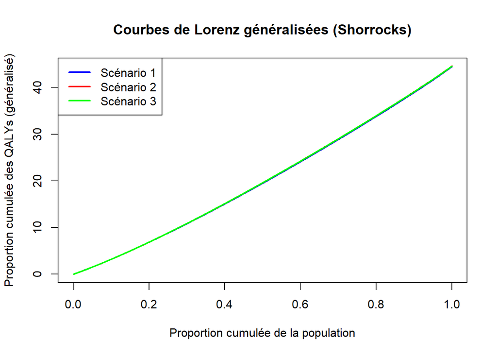

```r
#Théorème de Shorrocks

mean1 <- mean(fusion$qaly_stage1, na.rm = TRUE)
mean2 <- mean(fusion$qaly_stage_final2, na.rm = TRUE)
mean3 <- mean(fusion$qaly_stage_final3, na.rm = TRUE)

GL1 <- Lc1$L * mean1
GL2 <- Lc2$L * mean2
GL3 <- Lc3$L * mean3

# Tracer les courbes généralisées
plot(Lc1$p, GL1, type = "l", col = "blue", lwd = 2,
     xlab = "Proportion cumulée de la population",
     ylab = "Proportion cumulée des QALYs (généralisé)",
     main = "Courbes de Lorenz généralisées (Shorrocks)")
lines(Lc2$p, GL2, col = "red", lwd = 2)
lines(Lc3$p, GL3, col = "green", lwd = 2)
legend("topleft", legend = c("Scénario 1", "Scénario 2", "Scénario 3"),
       col = c("blue", "red", "green"), lty = 1, lwd = 2)
```

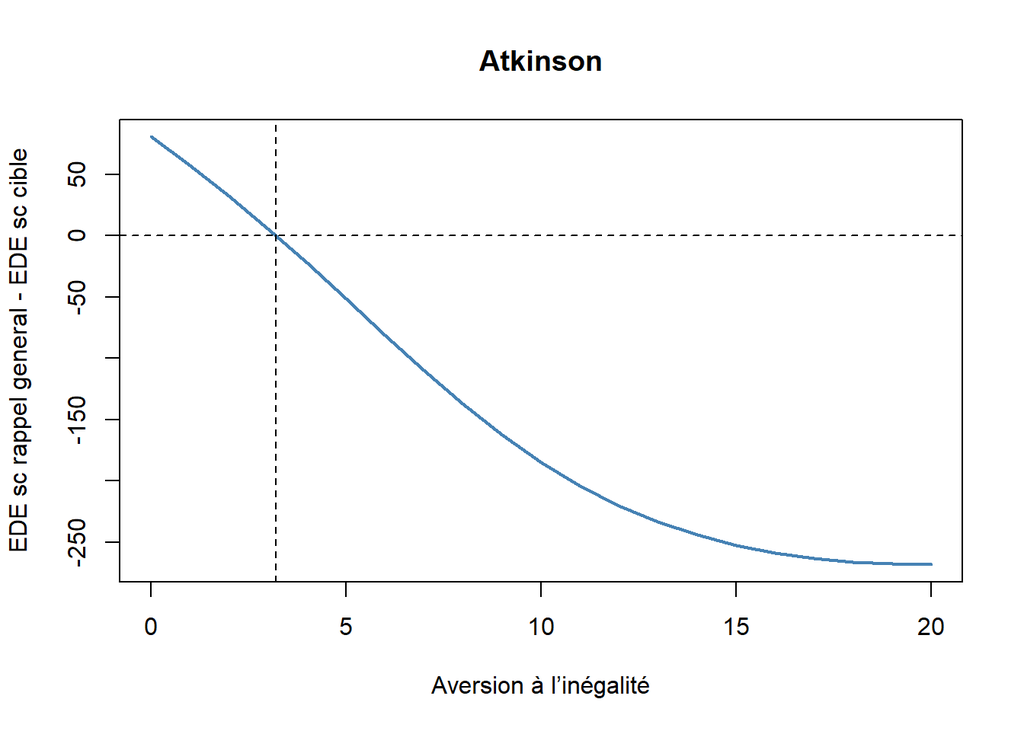

```r
EDE_atkinson = function(x, param){
  n=length(x)
  if (param == 1) {
    return(exp(mean(log(x))))
  } else {
    return(((1/n) * sum(x^(1 - param)))^(1 / (1 - param)))
  }}

epsilons = seq(0, 20, by = 1)
ede_target = sapply(epsilons, function(e) EDE_atkinson(fusion$qaly_stage_final3, param = e))
ede_universal = sapply(epsilons, function(e) EDE_atkinson(fusion$qaly_stage_final2, param = e))

diff_ede=ede_universal-ede_target

plot(epsilons, diff_ede*nrow(fusion), type = "l", lwd = 2, col = "steelblue",
     main="Atkinson",
     xlab = "Aversion à l’inégalité",
     ylab = "EDE sc rappel general - EDE sc cible")
abline(h = 0, col = "black", lty = 2)
abline(v = 3.2, col = "black", lty = 2)
```

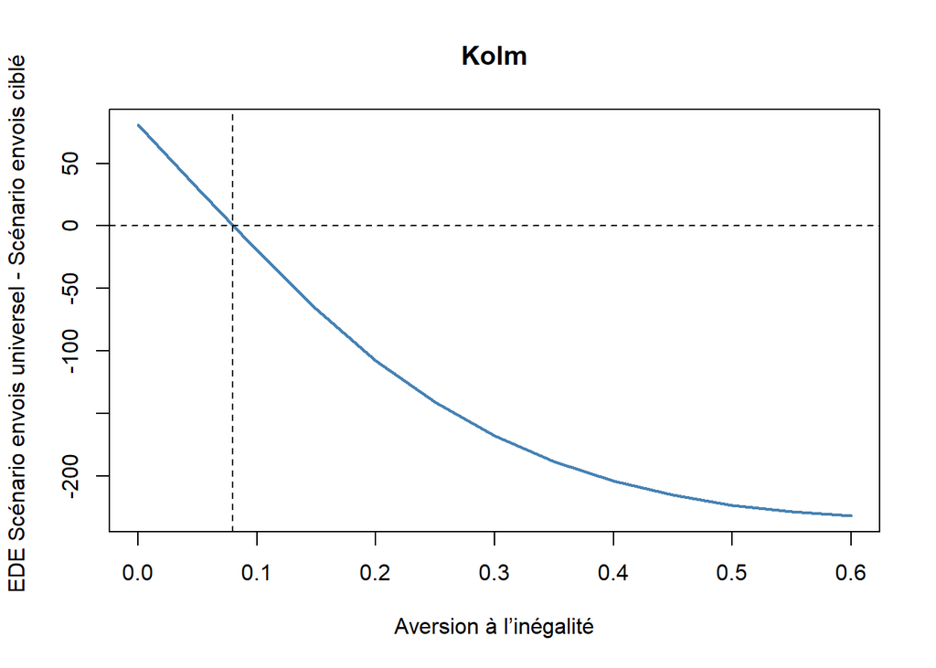

```r
#kolm
alpha = seq(0, 0.6, by = 0.05)

calculate_kolm_ede = function(x,param){
  if(param==0){
    ede = mean(x)
  } else {
    ede = (-1/param)*log(mean(exp(-param * x)))
  }
  return(ede)
}

ede_target_k = sapply(alpha, function(e) calculate_kolm_ede(fusion$qaly_stage_final3, param = e))
ede_universal_k = sapply(alpha, function(e) calculate_kolm_ede(fusion$qaly_stage_final2, param = e))

diff_ede_k=ede_universal_k-ede_target_k

plot(alpha, diff_ede_k*nrow(fusion), type = "l", lwd = 2, col = "steelblue",
     main="Kolm",
     xlab = "Aversion à l’inégalité",
     ylab = "EDE Scénario envois universel - Scénario envois ciblé ")
abline(h = 0, col = "black", lty = 2)
abline(v = 0.08, col = "black", lty = 2)
```